# ReneWind

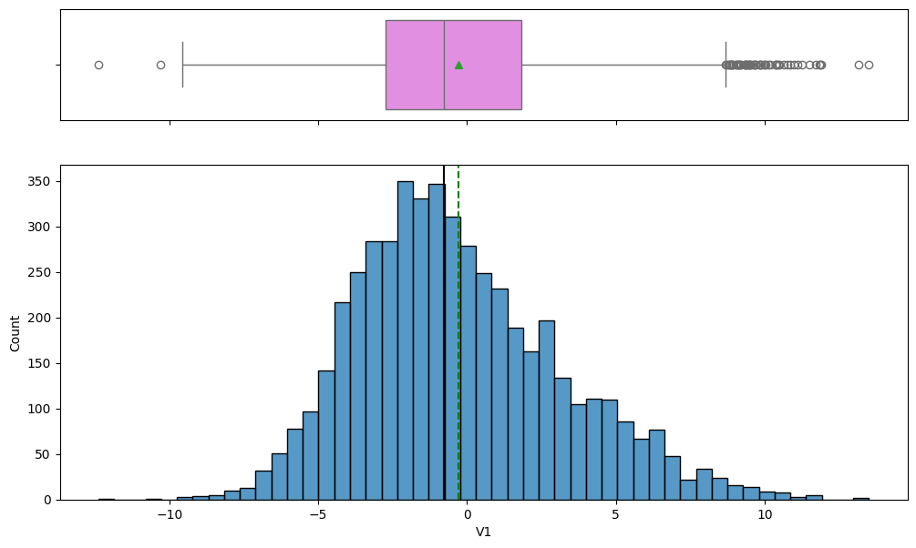

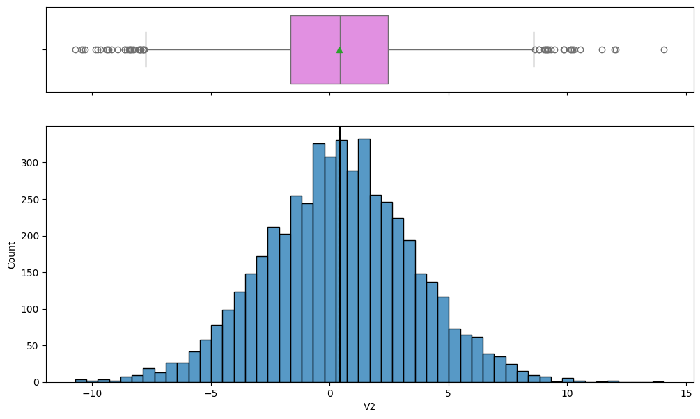

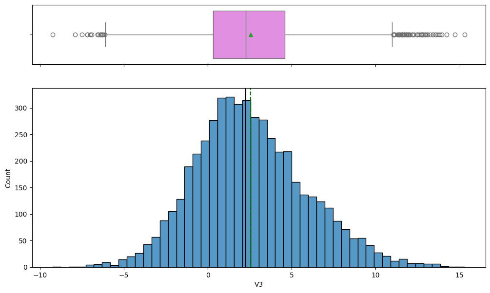

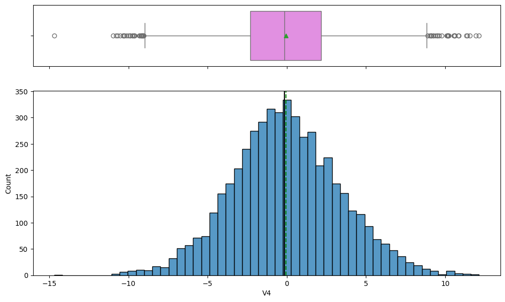

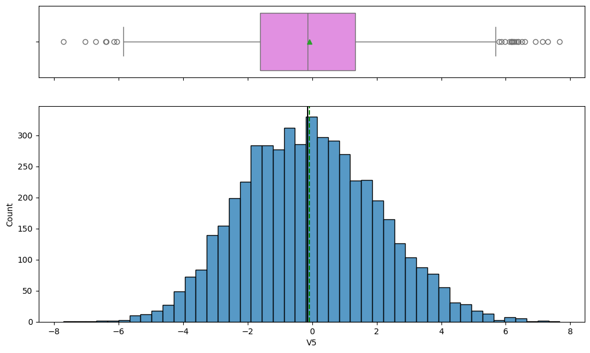

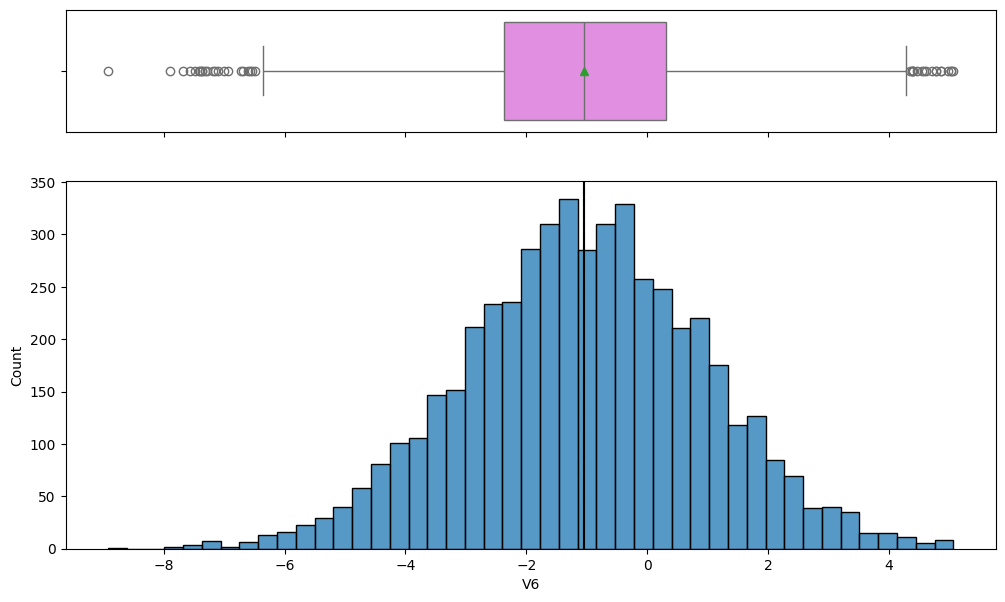

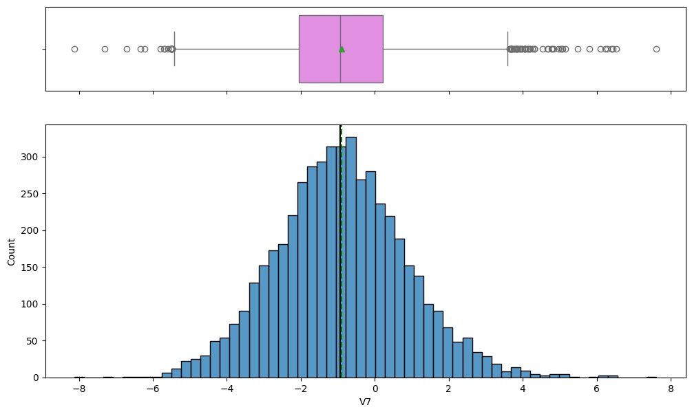

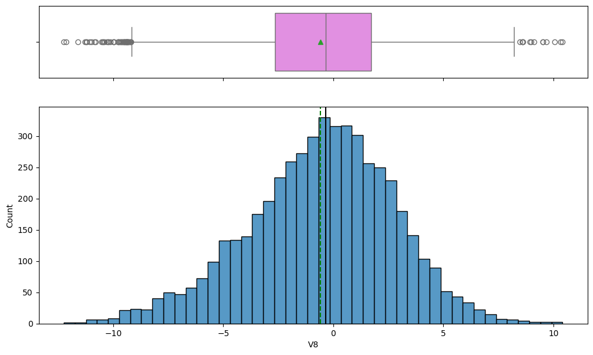

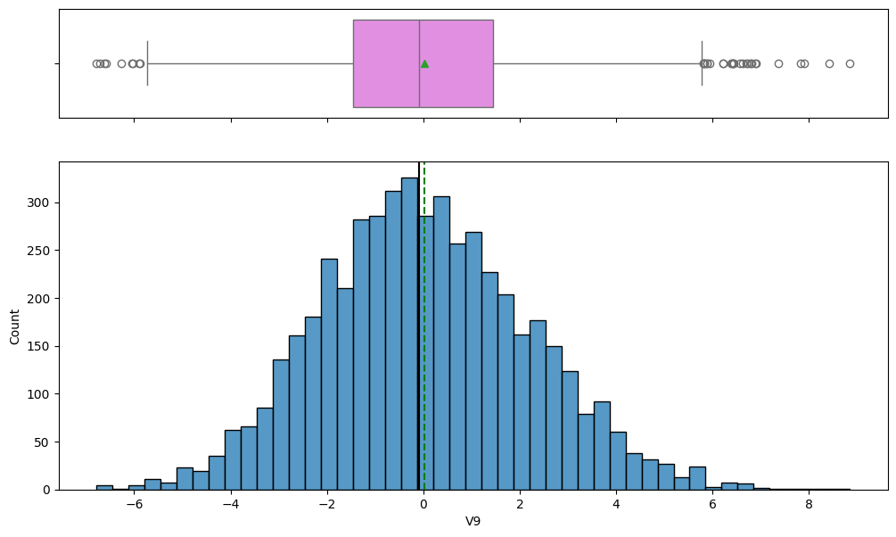

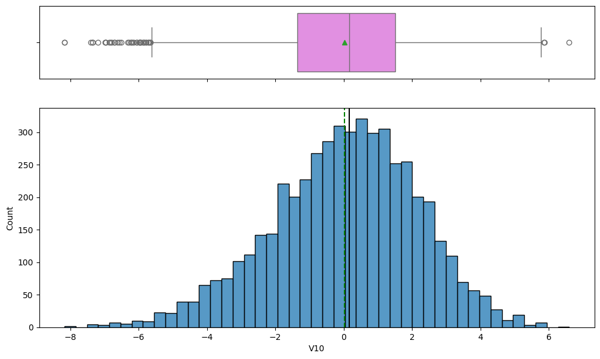

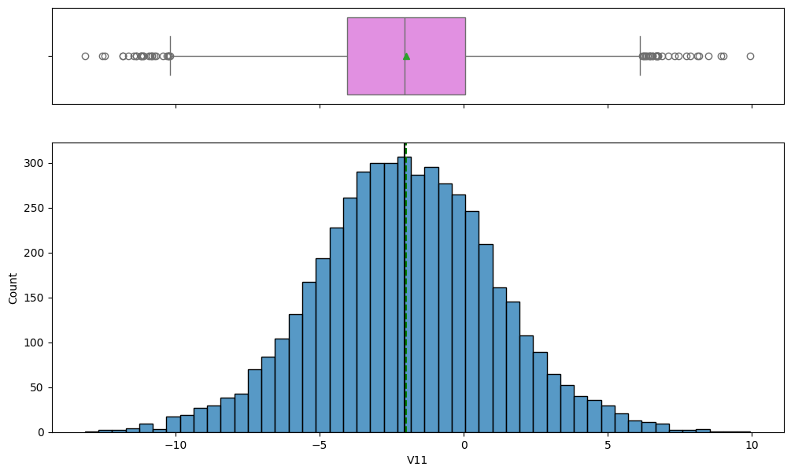

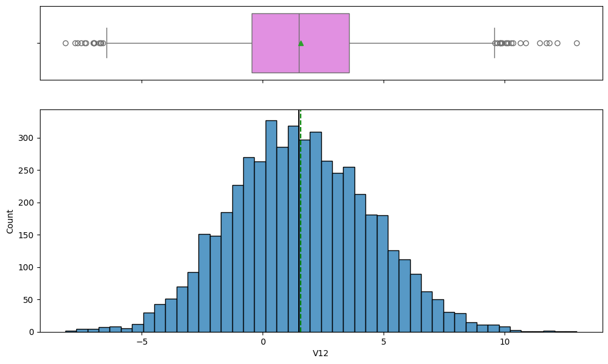

[29 more figures not shown]

```python
for feature in data_test.columns:
    histogram_boxplot(data_test, feature, figsize=(12, 7), kde=False, bins=None) ## Please change the dataframe name as you define while reading the data
```

```python
data["Target"].value_counts() ##  Complete the code to check the class distribution in target variable for train data
```

| Target | count |
| --- | --- |
| 0 | 18890 |
| 1 | 1110 |

**dtype:** int64

Our Training dataset is imbalance

```python
data_test["Target"].value_counts() ##  Complete the code to check the class distribution in target variable for test data
```

| Target | count |
| --- | --- |
| 0 | 4718 |
| 1 | 282 |

**dtype:** int64

Our Testing dataset is imbalance

## Data Pre-processing

```python
# Dividing train data into X and y
X = data.drop(["Target"], axis=1)
y = data["Target"]
```

Since i already have a separate test dataset, there is no need to further divide my training data into training, validation, and test sets. However, it’s still a common practice to divide the training data into train and validation sets to monitor model performance and prevent overfitting.

```python
X_train, X_val, y_train, y_val = train_test_split(X, y, test_size = 0.25, random_state = 42)
# X_train, y_train: Training data (75%)
# X_val, y_val: Validation data (25%)ratio 75:25
```

```python
X_train.shape ##  view dimensions of the X_train data


X_val.shape ##view dimensions of the X_val data
```

```
(5000, 40)
```

```python
# Dividing test data into X_test and y_test

X_test = data_test.drop(["Target"], axis=1) ##  Complete the code to drop target variable from test data
y_test =data_test["Target"] ##  Complete the code to store target variable in y_test
```

```python
X_test.shape ## view dimensions of the X_test data
```

```
(5000, 40)
```

## Missing value imputation

```python
# creating an instace of the imputer to be used
imputer = SimpleImputer(strategy="median")
```

This imputer will handle missing values in your dataset by replacing them with the median value of each column.

```python
# Fit and transform the train data
X_train = pd.DataFrame(imputer.fit_transform(X_train), columns=X_train.columns)

# Transform the validation data
X_val = pd.DataFrame(imputer.transform(X_val), columns=X_train.columns) ## Complete the code to impute missing values in X_val without data leakage

# Transform the test data
X_test = pd.DataFrame(imputer.transform(X_test), columns=X_train.columns) ## Complete the code to impute missing values in X_test without data leakage
```

```python
# Checking that no column has missing values in train or test sets
print(X_train.isna().sum())
print("-" * 30)

print(X_val.isna().sum()) ## Complete the code to check the count of missing values in validation set
print(X_test.isna().sum()) ## Complete the code to check the count of missing values in test set
```

```
V1     0
V2     0
V3     0
V4     0
V5     0
V6     0
V7     0
V8     0
V9     0
V10    0
V11    0
V12    0
V13    0
V14    0
V15    0
V16    0
V17    0
V18    0
V19    0
V20    0
V21    0
V22    0
V23    0
V24    0
V25    0
V26    0
V27    0
V28    0
V29    0
V30    0
V31    0
V32    0
V33    0
V34    0
V35    0
V36    0
V37    0
V38    0
V39    0
V40    0
```

[output cut: 69 more lines]

```
V27    0
V28    0
V29    0
V30    0
V31    0
V32    0
V33    0
V34    0
V35    0
V36    0
V37    0
V38    0
V39    0
V40    0
dtype: int64
```

## Model Building

### Model evaluation criterion

The nature of predictions made by the classification model will translate as follows:

- True positives (TP) are failures correctly predicted by the model.
- False negatives (FN) are real failures in a generator where there is no detection by model.
- False positives (FP) are failure detections in a generator where there is no failure.

**Which metric to optimize?**

- We need to choose the metric which will ensure that the maximum number of generator failures are predicted correctly by the model.
- We would want Recall to be maximized as greater the Recall, the higher the chances of minimizing false negatives.
- We want to minimize false negatives because if a model predicts that a machine will have no failure when there will be a failure, it will increase the maintenance cost.

**Let's define a function to output different metrics (including recall) on the train and test set and a function to show confusion matrix so that we do not have to use the same code repetitively while evaluating models.**

```python
# defining a function to compute different metrics to check performance of a classification model built using sklearn
def model_performance_classification_sklearn(model, predictors, target):
    """
    Function to compute different metrics to check classification model performance

    model: classifier
    predictors: independent variables
    target: dependent variable
    """

    # predicting using the independent variables
    pred = model.predict(predictors)

    acc = accuracy_score(target, pred)  # to compute Accuracy
    recall = recall_score(target, pred)  # to compute Recall
    precision = precision_score(target, pred)  # to compute Precision
    f1 = f1_score(target, pred)  # to compute F1-score

    # creating a dataframe of metrics
    df_perf = pd.DataFrame(
        {
            "Accuracy": acc,
            "Recall": recall,
            "Precision": precision,
            "F1": f1

        },
        index=[0],
    )

    return df_perf
```

```python
def confusion_matrix_sklearn(model, predictors, target):
    """
    To plot the confusion_matrix with percentages

    model: classifier
    predictors: independent variables
    target: dependent variable
    """
    y_pred = model.predict(predictors)
    cm = confusion_matrix(target, y_pred)
    labels = np.asarray(
        [
            ["{0:0.0f}".format(item) + "\n{0:.2%}".format(item / cm.flatten().sum())]
            for item in cm.flatten()
        ]
    ).reshape(2, 2)

    plt.figure(figsize=(6, 4))
    sns.heatmap(cm, annot=labels, fmt="")
    plt.ylabel("True label")
    plt.xlabel("Predicted label")
```

### Defining scorer to be used for cross-validation and hyperparameter tuning

- We want to reduce false negatives and will try to maximize "Recall".
- To maximize Recall, we can use Recall as a **scorer** in cross-validation and hyperparameter tuning.

```python
# Type of scoring used to compare parameter combinations
scorer = metrics.make_scorer(metrics.recall_score)
```

```python
# defining metric to be used for optimization and with cross-validation
def Minimum_Vs_Model_cost(y_train, y_pred):
    """
    We want the model to optimize the maintenance cost and reduce it to the lowest possible value.
    The lowest possible maintenance cost will be achieved when each sample is predicted correctly.

    In such a scenario, the maintenance cost will be the total number of failures times the maintenance cost of replacing one generator,
    which is given by (TP + FN) * 40 (i.e., the actual positives*40).
    For any other scenario,
    the maintenance cost associated with the model will be given by (TP * 15 + FP * 5 + FN * 40).

    We will use the ratio of these two maintenance costs as the cost function for our model.
    The greater the ratio, the lower the associated maintenance cost and the better the model.
    """
    TP = confusion_matrix(y_train, y_pred)[1, 1]
    FP = confusion_matrix(y_train, y_pred)[0, 1]
    FN = confusion_matrix(y_train, y_pred)[1, 0]
    return ((TP + FN) * 15) / (TP * 15 + FP * 5 + FN * 40)


# A value of .80 here, will represent that the minimum maintenance cost is 80% of the maintenance cost associated with the model.
# Since minimum maintenance cost is constant for any data, when minimum cost will become 100% of maintenance cost associated with the model
# Model will have give the least possible maintenance cost.


# Type of scoring used to compare parameter combinations
scorer = metrics.make_scorer(Minimum_Vs_Model_cost, greater_is_better=True)

# Higher the values, the lower the maintenance cost
```

### Model Building with original data

Sample Decision Tree model building with original data

```python
models = []  # Empty list to store all the models

# Appending models into the list

models.append(
    ("Logistic Regression", LogisticRegression(solver="newton-cg", random_state=1))
)
models.append(("dtree", DecisionTreeClassifier(random_state=1)))
models.append(("Random forest", RandomForestClassifier(random_state=1)))
models.append(("Bagging", BaggingClassifier(random_state=1)))
models.append(("Adaboost", AdaBoostClassifier(random_state=1)))
models.append(("GBM", GradientBoostingClassifier(random_state=1)))
models.append(("Xgboost", XGBClassifier(random_state=1, eval_metric="logloss")))

results = []  # Empty list to store all model's CV scores
names = []  # Empty list to store name of the models
score = []

# loop through all models to get the mean cross validated score

print("\n" "Cross-Validation Performance:" "\n")

for name, model in models:
    kfold = StratifiedKFold(
        n_splits=5, shuffle=True, random_state=1
    )  # Setting number of splits equal to 5
    cv_result = cross_val_score(
        estimator=model, X=X_train, y=y_train, scoring=scorer, cv=kfold
    )
    results.append(cv_result)
    names.append(name)
    print("{}: {}".format(name, cv_result.mean()))
```

```
Cross-Validation Performance:

Logistic Regression: 0.5333615067493349
dtree: 0.6518234448332685
Random forest: 0.6832744396236731
Bagging: 0.6668647909072949
Adaboost: 0.600001358406054
GBM: 0.6691004402833849
Xgboost: 0.747884978654481
```

Decision Tree: 0.65 This means that the Decision Tree model was able to correctly classify about 65% of the cases when evaluated on different parts of the training data. This performance is moderate and shows the model's ability to differentiate between the classes, but there is room for improvement.

Random Forest: 0.68 This means that the Random Forest model achieved a score of 68%, indicating it can correctly classify nearly 68% of the cases. The model performs better than the Decision Tree alone, likely due to its ensemble nature, which reduces overfitting and improves generalization.

Bagging: 0.67 This means that the Bagging model correctly identified about 67% of the cases during testing. It performs similarly to the Random Forest, which is expected since both are ensemble methods, but it offers slightly less accuracy in this scenario.

Adaboost: 0.60 This means that the Adaboost model was able to correctly classify around 60% of the cases. While this is a decent performance, it’s notably lower than the Random Forest and Bagging models, indicating it may not be as strong a performer for this task.

GBM: 0.67 This means that the Gradient Boosting model achieved a score of 67%, which is very similar to the Bagging model. Gradient Boosting is known for its ability to improve weak learners, and this score shows its effectiveness, although it performs slightly below Random Forest.

XGBoost: 0.75 This means that the XGBoost model excelled with a performance score of 75%, making it the best-performing model in this evaluation. XGBoost's strong predictive capabilities and advanced optimization techniques allow it to outperform other models in this comparison, making it a robust choice for your classification task.

```python
print("\n" "Training Performance:" "\n")

for name, model in models:
    model.fit(X_train, y_train)
    scores = Minimum_Vs_Model_cost(y_train, model.predict(X_train))
    print("{}: {}".format(name, scores))
```

```
Training Performance:

Logistic Regression: 0.5376573501173458
dtree: 1.0
Random forest: 1.0
Bagging: 0.9692307692307692
Adaboost: 0.6322127446061214
GBM: 0.7794618001855862
Xgboost: 1.0
```

```python
print("\n" "Validation Performance:" "\n")

for name, model in models:
    model.fit(X_train, y_train)
    scores = Minimum_Vs_Model_cost(y_val, model.predict(X_val))
    print("{}: {}".format(name, scores))
```

```
Validation Performance:

Logistic Regression: 0.5270006506180872
dtree: 0.6164383561643836
Random forest: 0.662847790507365
Bagging: 0.676126878130217
Adaboost: 0.5748757984386089
GBM: 0.6511254019292605
Xgboost: 0.743801652892562
```

The cross-validation training performance scores are relatively close to the validation scores, indicating that most models are generalizing well, except for those with a tendency to overfit, such as Decision Tree, Random Forest, Bagging, and XGBoost. The high training scores of these models (close to 1) compared to their validation scores suggest they may be fitting too closely to the training data.

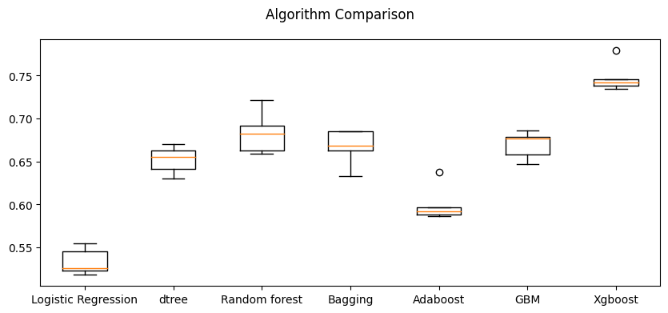

```python
# Plotting boxplots for CV scores of all models defined above

fig = plt.figure(figsize=(10, 4))

fig.suptitle("Algorithm Comparison")
ax = fig.add_subplot(111)

plt.boxplot(results)
ax.set_xticklabels(names)

plt.show()
```

### Model Building with Oversampled data

```python
print("Before OverSampling, counts of label '1': {}".format(sum(y_train == 1)))
print("Before OverSampling, counts of label '0': {} \n".format(sum(y_train == 0)))

# Synthetic Minority Over Sampling Technique
sm = SMOTE(sampling_strategy=1, k_neighbors=5, random_state=1)
X_train_over, y_train_over = sm.fit_resample(X_train, y_train)


print("After OverSampling, counts of label '1': {}".format(sum(y_train_over == 1)))
print("After OverSampling, counts of label '0': {} \n".format(sum(y_train_over == 0)))


print("After OverSampling, the shape of train_X: {}".format(X_train_over.shape))
print("After OverSampling, the shape of train_y: {} \n".format(y_train_over.shape))
```

```
Before OverSampling, counts of label '1': 840
Before OverSampling, counts of label '0': 14160

After OverSampling, counts of label '1': 14160
After OverSampling, counts of label '0': 14160

After OverSampling, the shape of train_X: (28320, 40)
After OverSampling, the shape of train_y: (28320,)
```

Oversampling is a technique used to address class imbalance by increasing the number of minority class samples to balance the dataset. In this case, the Synthetic Minority Over Sampling Technique (SMOTE) is used.

```python
models_over = []  # Empty list to store all the models

# Appending models into the list

models_over.append(
    ("Logistic Regression", LogisticRegression(solver="newton-cg", random_state=1))
)
models_over.append(("dtree", DecisionTreeClassifier(random_state=1)))
models_over.append(("Random forest", RandomForestClassifier(random_state=1)))
models_over.append(("Bagging", BaggingClassifier(random_state=1)))
models_over.append(("Adaboost", AdaBoostClassifier(random_state=1)))
models_over.append(("GBM", GradientBoostingClassifier(random_state=1)))
models_over.append(("Xgboost", XGBClassifier(random_state=1, eval_metric="logloss")))

results_over = []  # Empty list to store all model's CV scores
names_over = []  # Empty list to store name of the models
score_over = []

# loop through all models to get the mean cross validated score

print("\n" "Cross-Validation Performance:" "\n")

for name, model in models_over:
    kfold = StratifiedKFold(
        n_splits=5, shuffle=True, random_state=1
    )  # Setting number of splits equal to 5
    cv_result = cross_val_score(
        estimator=model, X=X_train_over, y=y_train_over, scoring=scorer, cv=kfold
    )
    results_over.append(cv_result)
    names_over.append(name)
    print("{}: {}".format(name, cv_result.mean()))
```

```
Cross-Validation Performance:

Logistic Regression: 0.8008759355996424
dtree: 0.9399009305846745
Random forest: 0.9742241960686189
Bagging: 0.9554548731532198
Adaboost: 0.8270035710705095
GBM: 0.8753875759153236
Xgboost: 0.983267700616431
```

```python
print("\n" "Training Performance:" "\n")

for name, model in models_over:
    model.fit(X_train_over, y_train_over)
    scores = Minimum_Vs_Model_cost(y_train_over, model.predict(X_train_over))
    print("{}: {}".format(name, scores))
```

```
Training Performance:

Logistic Regression: 0.8010711120330385
dtree: 1.0
Random forest: 1.0
Bagging: 0.9972065071950046
Adaboost: 0.831929810818221
GBM: 0.8817668548654932
Xgboost: 1.0
```

```python
print("\n" "Validation Performance:" "\n")

for name, model in models_over:
    model.fit(X_train_over, y_train_over)
    scores = Minimum_Vs_Model_cost(y_val, model.predict(X_val))
    print("{}: {}".format(name, scores))
```

```
Validation Performance:

Logistic Regression: 0.499691548426897
dtree: 0.6269349845201239
Random forest: 0.7773512476007678
Bagging: 0.7193605683836589
Adaboost: 0.5724381625441696
GBM: 0.7025151777970512
Xgboost: 0.7902439024390244
```

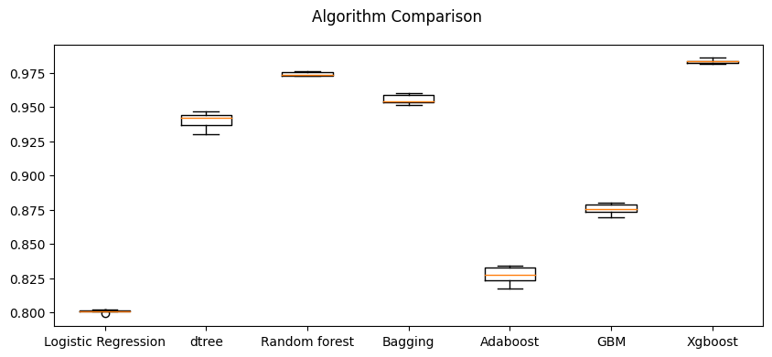

```python
# Plotting boxplots for CV scores of all models defined above

fig = plt.figure(figsize=(10, 4))

fig.suptitle("Algorithm Comparison")
ax = fig.add_subplot(111)

plt.boxplot(results_over)
ax.set_xticklabels(names)

plt.show()
```

### Model Building with Undersampled data

```python
rus = RandomUnderSampler(random_state=1, sampling_strategy=1)
X_train_un, y_train_un = rus.fit_resample(X_train, y_train)


print("Before UnderSampling, counts of label '1': {}".format(sum(y_train == 1)))
print("Before UnderSampling, counts of label '0': {} \n".format(sum(y_train == 0)))


print("After UnderSampling, counts of label '1': {}".format(sum(y_train_un == 1)))
print("After UnderSampling, counts of label '0': {} \n".format(sum(y_train_un == 0)))


print("After UnderSampling, the shape of train_X: {}".format(X_train_un.shape))
print("After UnderSampling, the shape of train_y: {} \n".format(y_train_un.shape))
```

```
Before UnderSampling, counts of label '1': 840
Before UnderSampling, counts of label '0': 14160

After UnderSampling, counts of label '1': 840
After UnderSampling, counts of label '0': 840

After UnderSampling, the shape of train_X: (1680, 40)
After UnderSampling, the shape of train_y: (1680,)
```

```python
models_un = []  # Empty list to store all the models

# Appending models into the list

models_un.append(
    ("Logistic Regression", LogisticRegression(solver="newton-cg", random_state=1))
)
models_un.append(("dtree", DecisionTreeClassifier(random_state=1)))
models_un.append(("Random forest", RandomForestClassifier(random_state=1)))
models_un.append(("Bagging", BaggingClassifier(random_state=1)))
models_un.append(("Adaboost", AdaBoostClassifier(random_state=1)))
models_un.append(("GBM", GradientBoostingClassifier(random_state=1)))
models_un.append(("Xgboost", XGBClassifier(random_state=1, eval_metric="logloss")))

results_un = []  # Empty list to store all model's CV scores
names_un = []  # Empty list to store name of the models
score_un = []

# loop through all models to get the mean cross validated score

print("\n" "Cross-Validation Performance:" "\n")

for name, model in models_un:
    kfold = StratifiedKFold(
        n_splits=5, shuffle=True, random_state=1
    )  # Setting number of splits equal to 5
    cv_result = cross_val_score(
        estimator=model, X=X_train_un, y=y_train_un, scoring=scorer, cv=kfold
    )
    results_un.append(cv_result)
    names_un.append(name)
    print("{}: {}".format(name, cv_result.mean()))
```

```
Cross-Validation Performance:

Logistic Regression: 0.7799632864167889
dtree: 0.7818166169251335
Random forest: 0.8453910480790631
Bagging: 0.8167427707832724
Adaboost: 0.7904135329530624
GBM: 0.8354566426751864
Xgboost: 0.8530318169032615
```

Logistic Regression and Adaboost, with cross-validation scores of 77.9% and 79.0% respectively, perform reasonably but tend to underperform compared to the more sophisticated ensemble methods. This indicates that while Logistic Regression and AdaBoost capture some patterns in the data, models like Random Forest and XGBoost are better suited for this task, likely due to their ability to capture non-linear relationships and complex interactions within the data.

This cross-validation approach provides a reliable estimate of how each model will generalize to unseen data, helping you choose the most effective model for your task based on its performance in cross-validation testing.

```python
print("\n" "Training Performance:" "\n")

for name, model in models_un:
    model.fit(X_train_un, y_train_un)
    scores = Minimum_Vs_Model_cost(y_train_un, model.predict(X_train_un))
    print("{}: {}".format(name, scores))
```

```
Training Performance:

Logistic Regression: 0.7867624102403996
dtree: 1.0
Random forest: 1.0
Bagging: 0.9578107183580388
Adaboost: 0.8402800933644549
GBM: 0.9061488673139159
Xgboost: 1.0
```

```python
print("\n" "Validation Performance:" "\n")

for name, model in models_un:
    model.fit(X_train_un, y_train_un)
    scores = Minimum_Vs_Model_cost(y_val, model.predict(X_val))
    print("{}: {}".format(name, scores))
```

```
Validation Performance:

Logistic Regression: 0.4888352444176222
dtree: 0.4421397379912664
Random forest: 0.6633906633906634
Bagging: 0.5882352941176471
Adaboost: 0.5205655526992288
GBM: 0.6537530266343826
Xgboost: 0.6699751861042184
```

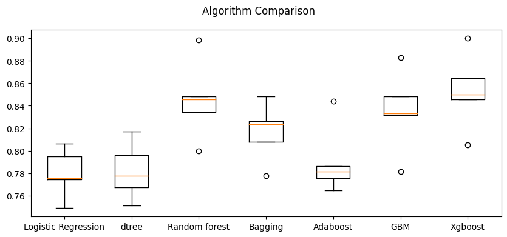

```python
# Plotting boxplots for CV scores of all models defined above

fig = plt.figure(figsize=(10, 4))

fig.suptitle("Algorithm Comparison")
ax = fig.add_subplot(111)

plt.boxplot(results_un)
ax.set_xticklabels(names)

plt.show()
```

## HyperparameterTuning

### Sample Parameter Grids

**Hyperparameter tuning can take a long time to run, so to avoid that time complexity - you can use the following grids, wherever required.**

- For Gradient Boosting:

param_grid = { "n_estimators": np.arange(100,150,25), "learning_rate": [0.2, 0.05, 1], "subsample":[0.5,0.7], "max_features":[0.5,0.7] }

- For Adaboost:

param_grid = { "n_estimators": [100, 150, 200], "learning_rate": [0.2, 0.05], "base_estimator": [DecisionTreeClassifier(max_depth=1, random_state=1), DecisionTreeClassifier(max_depth=2, random_state=1), DecisionTreeClassifier(max_depth=3, random_state=1), ] }

- For Bagging Classifier:

param_grid = { 'max_samples': [0.8,0.9,1], 'max_features': [0.7,0.8,0.9], 'n_estimators' : [30,50,70], }

- For Random Forest:

param_grid = { "n_estimators": [200,250,300], "min_samples_leaf": np.arange(1, 4), "max_features": [np.arange(0.3, 0.6, 0.1),'sqrt'], "max_samples": np.arange(0.4, 0.7, 0.1) }

- For Decision Trees:

param_grid = { 'max_depth': np.arange(2,6), 'min_samples_leaf': [1, 4, 7], 'max_leaf_nodes' : [10, 15], 'min_impurity_decrease': [0.0001,0.001] }

- For Logistic Regression:

param_grid = {'C': np.arange(0.1,1.1,0.1)}

- For XGBoost:

param_grid={ 'n_estimators': [150, 200, 250], 'scale_pos_weight': [5,10], 'learning_rate': [0.1,0.2], 'gamma': [0,3,5], 'subsample': [0.8,0.9] }

### Sample tuning method for Decision tree with original data

```python
# Defining the Decision Tree model
Model = DecisionTreeClassifier(random_state=1)

# Parameter grid for RandomizedSearchCV
param_grid = {
    'max_depth': np.arange(2, 6),  # Exploring depths from 2 to 5
    'min_samples_leaf': [1, 4, 7],  # Leaf sizes of 1, 4, or 7
    'max_leaf_nodes': [10, 15],  # Maximum number of leaf nodes 10 or 15
    'min_impurity_decrease': [0.0001, 0.001]  # Impurity decrease threshold
}

# Custom scoring function (replace this with your actual function)
def Minimum_Vs_Model_cost(y_true, y_pred):
    # Dummy function, replace with your real cost function
    return metrics.accuracy_score(y_true, y_pred)

# Type of scoring used to compare parameter combinations
scorer = metrics.make_scorer(Minimum_Vs_Model_cost, greater_is_better=True)

# Calling RandomizedSearchCV
randomized_cv = RandomizedSearchCV(
    estimator=Model,
    param_distributions=param_grid,
    n_iter=10,  # Number of random iterations
    n_jobs=-1,  # Use all processors
    scoring=scorer,
    cv=5,  # 5-fold cross-validation
    random_state=1
)

# Fitting RandomizedSearchCV with the training data
randomized_cv.fit(X_train, y_train)

# Printing the best parameters and corresponding score
print("Best parameters are {} with CV score={}:".format(randomized_cv.best_params_, randomized_cv.best_score_))
```

```
Best parameters are {'min_samples_leaf': 7, 'min_impurity_decrease': 0.0001, 'max_leaf_nodes': 15, 'max_depth': 5} with CV score=0.9697333333333333:
```

```python
# Alternative scoring (Recall Score Example)
scorer_recall = metrics.make_scorer(metrics.recall_score)  # Using recall as a scoring metric

# Calling RandomizedSearchCV again with recall as scoring
randomized_cv_recall = RandomizedSearchCV(
    estimator=Model,
    param_distributions=param_grid,
    n_iter=50,  # You can adjust the number of iterations
    scoring=scorer_recall,  # Now using recall as the metric
    cv=5,  # 5-fold cross-validation
    random_state=1,
    n_jobs=-1,  # Use all available cores
)

# Fitting RandomizedSearchCV with the training data
randomized_cv_recall.fit(X_train, y_train)

# Printing the best parameters and corresponding score for recall
print("Best parameters with recall scoring are {} with CV score={}:" .format(randomized_cv_recall.best_params_, randomized_cv_recall.best_score_))
```

```
Best parameters with recall scoring are {'min_samples_leaf': 4, 'min_impurity_decrease': 0.0001, 'max_leaf_nodes': 15, 'max_depth': 5} with CV score=0.5476190476190477:
```

```python
# Calculate performance metrics on the training set for the best DecisionTreeClassifier model
decision_tree_random_train = model_performance_classification_sklearn(
    randomized_cv_recall.best_estimator_, X_train, y_train
)

# Print training performance metrics for DecisionTreeClassifier
print("Training performance metrics for DecisionTreeClassifier:")
print(decision_tree_random_train)
```

```
Training performance metrics for DecisionTreeClassifier:
   Accuracy  Recall  Precision    F1
0     0.974   0.611      0.892 0.725
```

The best hyperparameters using RandomizedSearchCV for the DecisionTreeClassifier model were found to be: min_samples_leaf = 4, min_impurity_decrease = 0.0001, max_leaf_nodes = 15, and max_depth = 5.

### Sample tuning method for Decision tree with oversampled data

```python
# defining model
Model = DecisionTreeClassifier(random_state=1)

# Parameter grid to pass in RandomSearchCV
param_grid = {'max_depth': np.arange(2,6),
              'min_samples_leaf': [1, 4, 7],
              'max_leaf_nodes' : [10,15],
              'min_impurity_decrease': [0.0001,0.001] }

              # Custom scoring function (replace this with your actual function)
def Minimum_Vs_Model_cost(y_true, y_pred):
    # Dummy function, replace with your real cost function
    return metrics.accuracy_score(y_true, y_pred)

# Scorer using the custom function
scorer = metrics.make_scorer(Minimum_Vs_Model_cost, greater_is_better=True)


#Calling RandomizedSearchCV
randomized_cv = RandomizedSearchCV(estimator=Model, param_distributions=param_grid, n_iter=10, n_jobs = -1, scoring=scorer, cv=5, random_state=1)

#Fitting parameters in RandomizedSearchCV
randomized_cv.fit(X_train_over,y_train_over)

print("Best parameters are {} with CV score={}:" .format(randomized_cv.best_params_,randomized_cv.best_score_))
```

```
Best parameters are {'min_samples_leaf': 7, 'min_impurity_decrease': 0.0001, 'max_leaf_nodes': 15, 'max_depth': 5} with CV score=0.896680790960452:
```

```python
# Assuming you have your original data in X and y
# Perform oversampling (replace with your actual oversampling method)
from imblearn.over_sampling import RandomOverSampler

# Assuming 'X' and 'y' are your original features and target
oversampler = RandomOverSampler(random_state=1)
X_train_oversampled, y_train_oversampled = oversampler.fit_resample(X_train, y_train)


# Calculate performance metrics on the training set for the best DecisionTreeClassifier model (using recall-based scoring)
decision_tree_random_train = model_performance_classification_sklearn(
    randomized_cv_recall.best_estimator_, X_train_oversampled, y_train_oversampled
)

# Print training performance metrics for DecisionTreeClassifier
print("Training performance metrics for DecisionTreeClassifier:")
print(decision_tree_random_train)
```

```
Training performance metrics for DecisionTreeClassifier:
   Accuracy  Recall  Precision    F1
0     0.804   0.612      0.993 0.757
```

Model Performance: The cross-validation score (0.897) suggests that the Decision Tree classifier performs quite well on the training data. This score indicates a good level of generalization, with an expectation of achieving similar performance on unseen data.

Overfitting Risk: Although the model shows high precision (0.993), the recall is relatively lower (0.612), suggesting that the model may be highly precise in its predictions but could be missing a significant number of true positives. This can be interpreted as the model being slightly overfit to the training data, as it performs exceedingly well on the training set but may not generalize equally well across all instances.

Precision vs. Recall Tradeoff: The high precision implies the model makes fewer false positives, but the recall being lower suggests that it doesn't catch all relevant positive cases. The relatively lower recall combined with a higher precision indicates the model might be biased toward minimizing false positives, potentially at the cost of missing some true positives.

Generalization Ability: While the training performance shows a reasonable F1 score (0.757), the discrepancy between the high precision and lower recall could indicate the model might need further tuning or regularization to achieve a better balance between recall and precision.

### Sample tuning method for Decision tree with undersampled data

```python
# defining model
Model = DecisionTreeClassifier(random_state=1)

# Parameter grid to pass in RandomSearchCV
param_grid = {'max_depth': np.arange(2,20),
              'min_samples_leaf': [1, 2, 5, 7],
              'max_leaf_nodes' : [5, 10,15],
              'min_impurity_decrease': [0.0001,0.001] }

# Custom scoring function (replace this with your actual function)
def Minimum_Vs_Model_cost(y_true, y_pred):
    # Dummy function, replace with your real cost function
    return metrics.accuracy_score(y_true, y_pred)

# Scorer using the custom function
scorer = metrics.make_scorer(Minimum_Vs_Model_cost, greater_is_better=True)


#Calling RandomizedSearchCV
randomized_cv = RandomizedSearchCV(estimator=Model, param_distributions=param_grid, n_iter=10, n_jobs = -1, scoring=scorer, cv=5, random_state=1)

#Fitting parameters in RandomizedSearchCV
randomized_cv.fit(X_train_un,y_train_un)

print("Best parameters are {} with CV score={}:" .format(randomized_cv.best_params_,randomized_cv.best_score_))
```

```
Best parameters are {'min_samples_leaf': 2, 'min_impurity_decrease': 0.001, 'max_leaf_nodes': 15, 'max_depth': 6} with CV score=0.8708333333333332:
```

```python
# Calculate performance metrics on the training set for the best DecisionTreeClassifier model (using recall-based scoring)
decision_tree_random_train = model_performance_classification_sklearn(
    randomized_cv_recall.best_estimator_, X_train_oversampled, y_train_oversampled
)

# Print training performance metrics for DecisionTreeClassifier
print("Training performance metrics for DecisionTreeClassifier:")
print(decision_tree_random_train)
```

```
Training performance metrics for DecisionTreeClassifier:
   Accuracy  Recall  Precision    F1
0     0.804   0.612      0.993 0.757
```

Generalization: The cross-validation score of 0.871 indicates that the Decision Tree model is performing well with the undersampled data, suggesting the model has a reasonable ability to generalize. Undersampling helps in addressing imbalanced classes, potentially improving the model’s performance in identifying minority class samples.

Precision vs. Recall Tradeoff: The very high precision shows that the model is effective at correctly identifying positive samples without producing many false positives. However, the relatively lower recall suggests the model still misses some true positives. A deeper exploration of the model’s bias-variance tradeoff might be necessary, particularly if catching all relevant cases (higher recall) is more critical for the task.

Potential Improvements: To mitigate overfitting further, techniques like pruning the decision tree, tweaking the impurity decrease threshold, or using more sophisticated resampling methods (e.g., SMOTE or undersampling with more balanced class weights) could help strike a better balance between precision and recall.